# Threatened Species

Doing some year based outlier analysis,

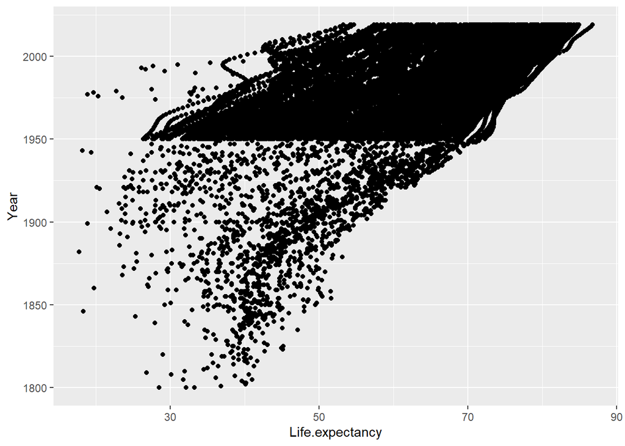

```r
ggplot(data = life1, aes(x = Life.expectancy, y = Year))+
  geom_point()
```

This plot clearly shows that main concentration of the data is mainly towards the upper part i.e more than 1950s. And this plot strengthen our assumption that the outliers are due to a particular country. In that case we can’t discard them.

Now as there are so many countries, graphical analysis of each and every country is nearly impossible. So, making a function that would detect that for us.

```r
outlier = function(x,y){
  vec = c()
  out = c()
    for(i in levels(y)){
   get =   x%>%filter(Entity == i)
        for(j in get$Life.expectancy){

          q1 = quantile(get$Life.expectancy, 0.25)
          q3 = quantile(get$Life.expectancy, 0.75)
          iqr = q3 - q1
          if(j < q1 - 1.5*iqr | j > q3 + iqr*1.5){
            out = append(out,j)
            if(! i %in% vec){
              vec = append(vec,i)

            }

            }

        }
    }
  return(list("coun" = vec, "life"  = out))
}

out = outlier(life1, life1$Entity)
out$coun
```

```
##  [1] "Africa"              "Americas"            "Angola"
##  [4] "Argentina"           "Aruba"               "Australia"
##  [7] "Austria"             "Barbados"            "Belarus"
## [10] "Brazil"              "Bulgaria"            "Burundi"
## [13] "Cameroon"            "Canada"              "Colombia"
## [16] "Congo"               "Costa Rica"          "Cuba"
## [19] "Cyprus"              "Czech Republic"      "Dominican Republic"
## [22] "El Salvador"         "Estonia"             "Europe"
## [25] "Fiji"                "Georgia"             "Germany"
## [28] "Ghana"               "Greece"              "Greenland"
## [31] "Guyana"              "Hungary"             "Iraq"
## [34] "Ireland"             "Japan"               "Kazakhstan"
## [37] "Kenya"               "Kuwait"              "Latvia"
## [40] "Lithuania"           "Malawi"              "Mauritius"
## [43] "Moldova"             "Montenegro"          "North Korea"
## [46] "Oceania"             "Pakistan"            "Panama"
## [49] "Paraguay"            "Philippines"         "Poland"
## [52] "Puerto Rico"         "Romania"             "Russia"
## [55] "Rwanda"              "Serbia"              "Sierra Leone"
## [58] "Slovakia"            "South Korea"         "Sri Lanka"
## [61] "Tanzania"            "Trinidad and Tobago" "Uganda"
## [64] "Ukraine"             "Uruguay"             "Venezuela"
## [67] "World"               "Zambia"
```

So there are 68 countries with outliers. Let’s take a country and do it’s boxplot to check if our function is working

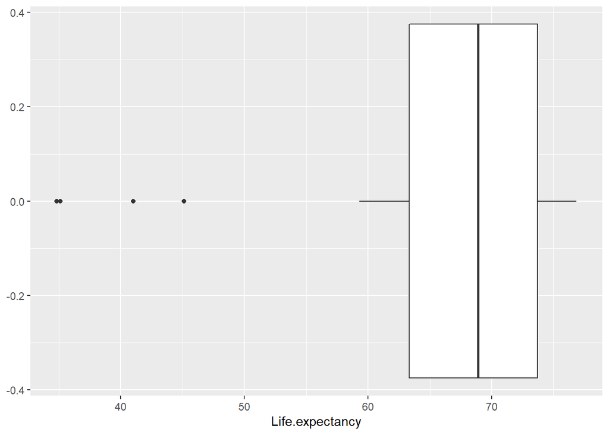

```r
life1%>%
  filter(Entity %in% c("Americas"))%>%
  ggplot(data = ., aes(x = Life.expectancy))+
  geom_boxplot()
```

And yes there are 4 outliers. So, our function is working.

Let us do a plot of the outliers on the basis of year.

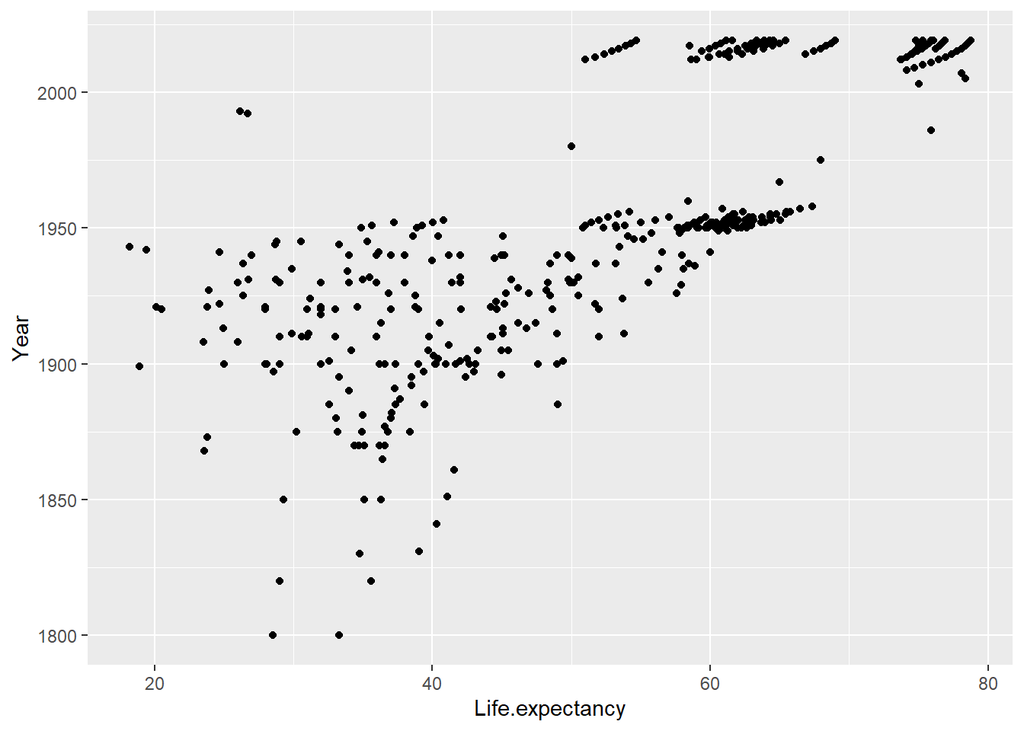

```r
life1%>%
  filter(Entity %in% out$coun & Life.expectancy %in% out$life)%>%
  ggplot(data = ., mapping = aes(x = Life.expectancy, y = Year)) +
  geom_point()
```

So, max outliers are taken around or less than 1950. So, we can consider eliminating them. But before that let us do a quick analysis of number of outliers on basis of a country.

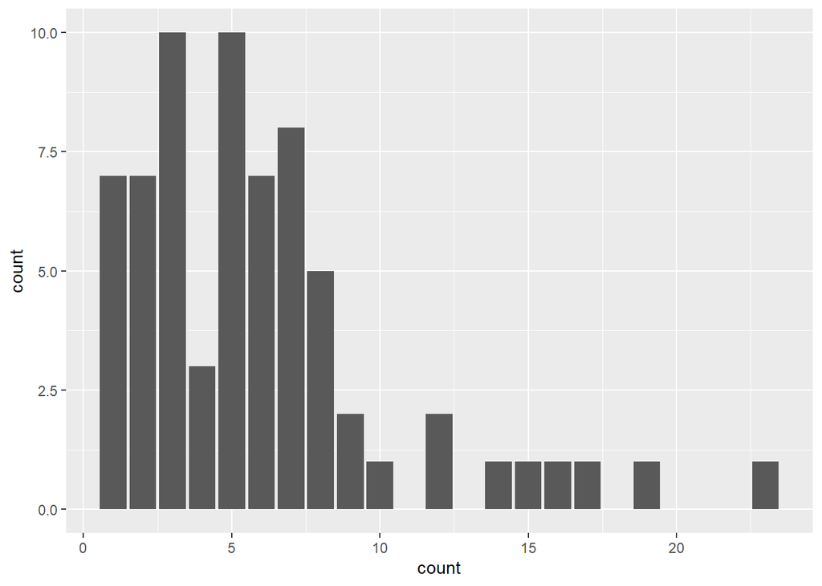

```r
life1%>%
  filter(Entity %in% out$coun & Life.expectancy %in% out$life)%>%
  group_by(Entity)%>%
  summarize(count = n())%>%
  ggplot(data = ., aes(x = count))+
  geom_bar()
```

This is surprising because there are some countries which has more than 10 outliers. Let us filter and remove those entries which has less than 10 outliers and focus more on the bigger counterparts.

```r
life6 = life1%>%
  filter(Entity %in% out$coun & Life.expectancy %in% out$life)%>%
  group_by(Entity)%>%
  summarize(count = n())%>%
  filter(count < 10)

life1 = life1%>%
  filter(!(Entity %in% life6$Entity & Life.expectancy %in% out$life))

outlier = life1%>%
  filter(Entity %in% out$coun & Life.expectancy %in% out$life)%>%
  group_by(Entity)%>%
  summarize(count = n())%>%
  filter(count > 10)

outlier
```

```
## # A tibble: 8 x 2
##   Entity    count
##   <fct>     <int>
## 1 Bulgaria     15
## 2 Estonia      23
## 3 Greece       12
## 4 Hungary      14
## 5 Latvia       17
## 6 Lithuania    19
## 7 Uganda       12
## 8 Ukraine      16
```

Ad so we got the countries with max outliers. Let us do a box plot of these 8 countries to understand more about them.

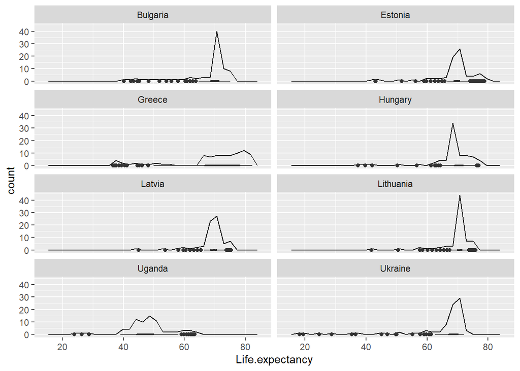

```r
life1 %>%
  filter(Entity %in% outlier$Entity)%>%
  ggplot(data = ., aes(x = Life.expectancy))+
  geom_freqpoly()+
  geom_boxplot()+
  facet_wrap(~Entity, ncol = 2)
```

Now these boxplots clearly shows that not all records can be removed. BUt clearly the outliers with life expenctancy less than 55 years are safe to be removed.

```r
life1 = life1%>%
  filter(!(Entity %in% outlier$Entity & Life.expectancy < 55))
```

### EDA

Since, this is a life expectancy dataset, let us dive some deeper into the life expectancy values and try to know what is the scenario of life all over the world.

```r
life1%>%
  count(cut_interval(as.integer(Year),10))
```

```
## # A tibble: 10 x 2
##    `cut_interval(as.integer(Year), 10)`     n
##    <fct>                                <int>
##  1 [1.8e+03,1.82e+03]                      34
##  2 (1.82e+03,1.84e+03]                     70
##  3 (1.84e+03,1.87e+03]                    171
##  4 (1.87e+03,1.89e+03]                    234
##  5 (1.89e+03,1.91e+03]                    329
##  6 (1.91e+03,1.93e+03]                    426
##  7 (1.93e+03,1.95e+03]                   1358
##  8 (1.95e+03,1.98e+03]                   5310
##  9 (1.98e+03,2e+03]                      5321
## 10 (2e+03,2.02e+03]                      5287
```

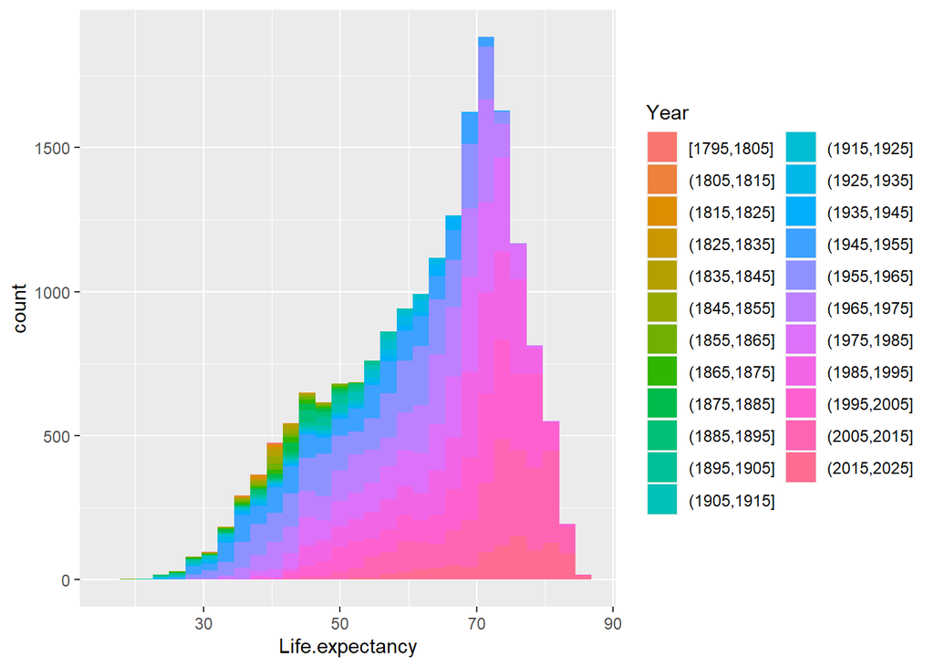

```r
ggplot(data = life1, aes(x= Life.expectancy, fill = cut_width(Year,10)))+
  geom_histogram()+
  labs(fill = "Year")
```

As the plot suggests, as time progressed, people’s life expectancy increased and tend to concentrate more around 70s. But I am more interested on least and most life expectant countries. So let’s do a closer look.

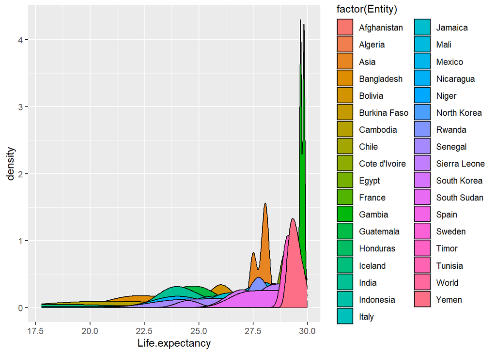

```r
life1%>%
  filter(Life.expectancy < 30)%>%
  ggplot(data = ., aes(x= Life.expectancy, fill = factor(Entity)))+
  geom_density()
```

So, some interesting results like Bangladesh, India on the list with a low desity sweeping around the low life mark whereas that of Asia and World have moderately good density around 30 years.

So we get to know that at certain periods of time, life was our continent/world was pretty tough to a high extent.

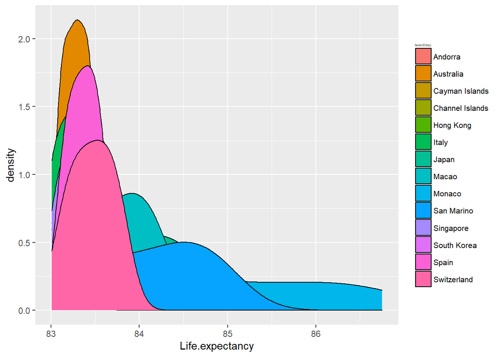

```r
life1%>%
  filter(Life.expectancy > 83)%>%
  ggplot(data = ., aes(x= Life.expectancy, fill = factor(Entity)))+
  geom_density()+
  guides(shape = guide_legend(override.aes = list(size = 0.5)))+
  theme(legend.title = element_text(size = 3), legend.text = element_text(size = 8))
```

Now, let’s measure the growth or the development of countries by analysing Life expectancy with time.

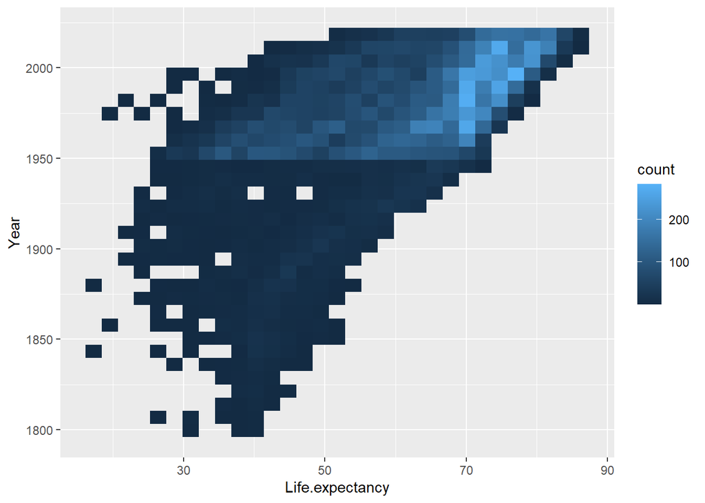

```r
ggplot(data = life1, aes(x = Life.expectancy, y = Year))+
  geom_bin2d()
```

So, this plot clearly shows that at the late 20th Century or the early 21st century led to an huge rise of Life expectancy.

Going out of overall analysis and going into specific analysis of all the Continents, World and India.

Let’s start by growth analysis.

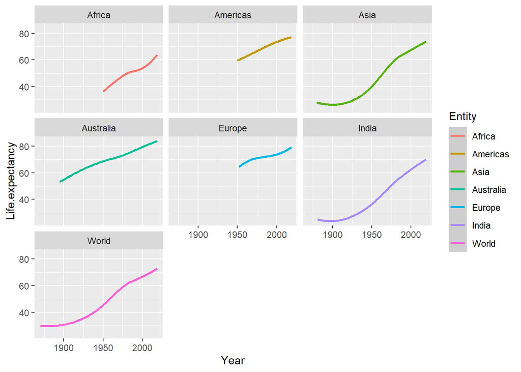

```r
country = c("India", "Americas", "Africa", "Asia", "Australia", "Europe", "World")
scale_value = 1
life1 %>%
  filter(Entity %in% country)%>%
  ggplot(data = ., aes(x = Year, y = Life.expectancy, color = Entity))+
  geom_smooth()+
  facet_wrap(~Entity)
```

From a very low expectancy rate to a considerable expecatancy rate, the growth of India shows that it is developing and so is the case all over the world.

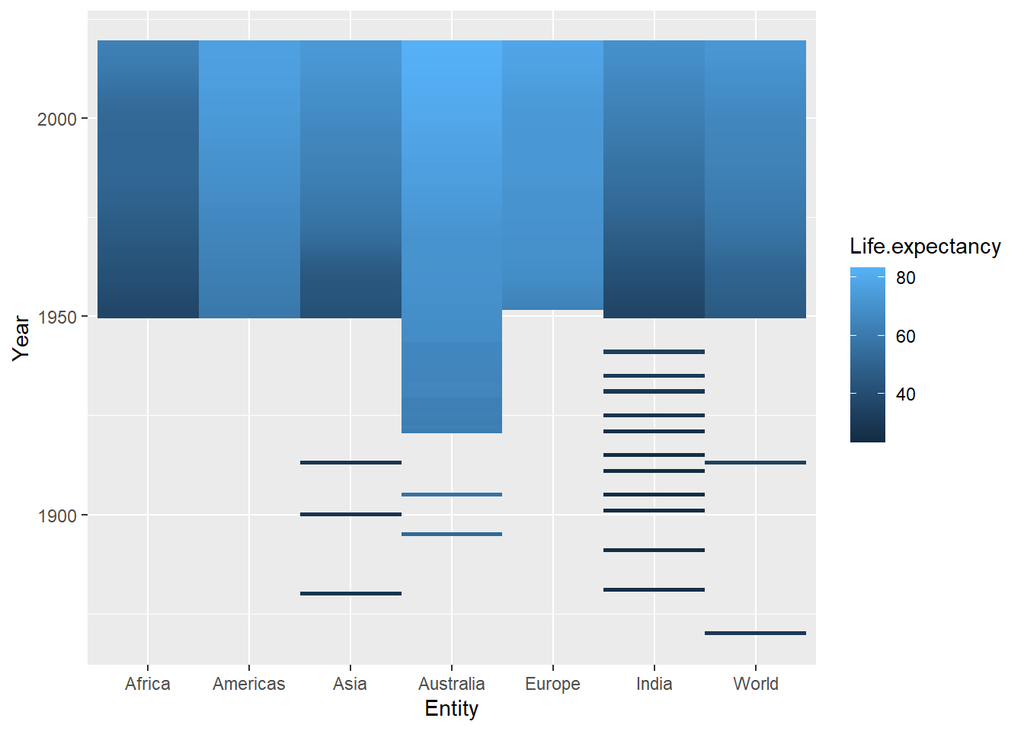

```r
life1 %>%
  filter(Entity %in% country)%>%
  ggplot(data = ., aes(x = Entity, y = Year, fill = Life.expectancy))+
  geom_tile()
```

This plot gives us an idea that most of teh analysis is tinkered and the records of India and World are mainly influenced by low availability of records. But as a whole they are below average whereas Americas and Australlia has pretty high average.

A closer look at India.

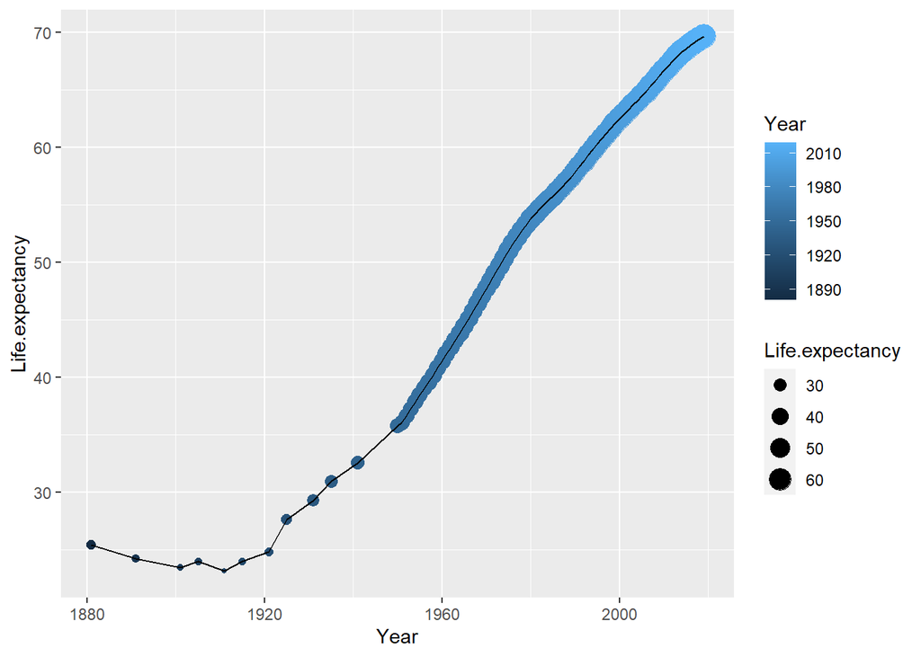

```r
life1 %>%
  filter(Entity == "India")%>%
  ggplot(data = ., aes(x = Year, y = Life.expectancy))+
  geom_point(aes(size= Life.expectancy, color = Year))+
  geom_line()
```

THis graph proves that our deduction is correct.

# Results and Discussions

The whole descriptive statistical analysis is

```r
life1 %>%
  filter(Entity %in% country)%>%
  group_by(Entity)%>%
  summarise(mean(Life.expectancy), min(Life.expectancy), max(Life.expectancy))
```

```
## # A tibble: 7 x 4
##   Entity    `mean(Life.expectancy)` `min(Life.expectancy)` `max(Life.expectancy~
##   <fct>                       <dbl>                  <dbl>                 <dbl>
## 1 Africa                       49.8                   36.4                  63.2
## 2 Americas                     69.1                   59.3                  76.8
## 3 Asia                         58.6                   27.5                  73.6
## 4 Australia                    72.3                   53.0                  83.4
## 5 Europe                       72.1                   63.3                  78.6
## 6 India                        50.7                   23.1                  69.7
## 7 World                        60.2                   29.7                  72.6
```

And the graphical analysis of the findings **

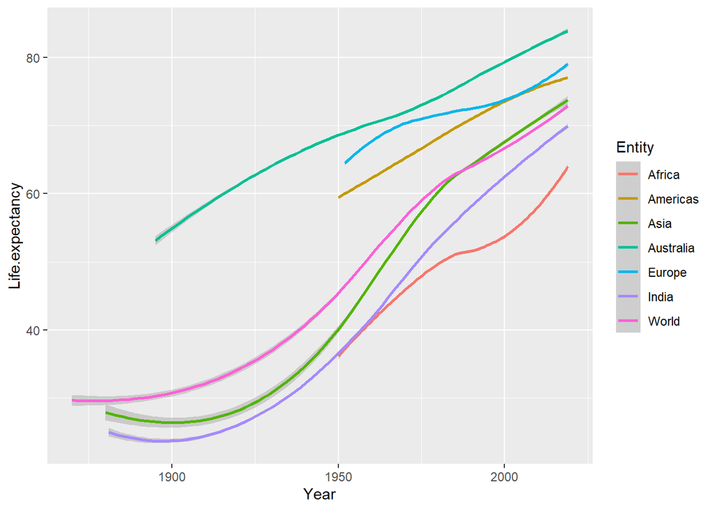

```r
life1 %>%
  filter(Entity %in% country)%>%
  ggplot(data = ., aes(x = Year, y = Life.expectancy, color = Entity))+
  geom_smooth()
```

So the highest LIfe Expectancy is of Australlia. And Africa, Asia and India’s life expectancy is below the world average and mainly affected by low Records.

# References

#### Exploratory Data Analysis: https://r4ds.had.co.nz/exploratory-data-analysis.html